# eforest(): Random Forests With Energy Trees as Base Learners

# Introduction

`etree` is the R package where Energy Trees (Giubilei et al., 2022) are implemented. The model allows to perform classification and regression with covariates that are possibly structured and of different types.

Energy Trees are used as base learners in ensemble methods that are the equivalent of bagging and Random Forests with traditional decision trees. The two resulting models are bagging of Energy Trees and Random Energy Forests, respectively.

This vignette explains how these two models can be used in R for classification and regression tasks. Both models are implemented using the function `eforest()`. The variables’ types included in the examples are those currently available in the package: numeric, nominal, functional, and in the form of graphs.

The first thing to do to run the examples is loading the package `etree`.

```r
library(etree)
```

# Data generation

The corresponding R object must be of class `“numeric”` to be correctly recognized by `eforest()` as a response variable for regression.

```r
# Set seed
set.seed(123)

# Number of observation
n_obs <- 100

# Response variable for regression
resp_reg <- c(rnorm(n_obs / 4, mean = 0, sd = 1),
              rnorm(n_obs / 4, mean = 2, sd = 1),
              rnorm(n_obs / 4, mean = 4, sd = 1),
              rnorm(n_obs / 4, mean = 6, sd = 1))
```

The response for classification is a nominal variable measured at four different levels: $1, 2, 3, 4$. For each group, observations are randomly assigned one of the four levels. The probability distribution is different for each group, and it gives the largest probability to the level equal to the index of the group, uniformly allocating the rest to the other three levels. For example, the response variable for the first group is the following:

$$Y^C_i \sim \begin{cases}
1 & p = 0.85 \\
2 & p = 0.05 \\
3 & p = 0.05 \\
4 & p = 0.05
\end{cases},
\quad \text{for} \; i \in G_1.$$

The same holds for $G_2, G_3, G_4$, except for switching each time the probabilities in such a way that the most probable level matches the index of the group.

The response variable for classification must be defined as a `factor` to be correctly identified by `eforest()`.

```r
# Response variable for classification
resp_cls <- factor(c(sample(x = 1:4, size = n_obs / 4, replace = TRUE,
                            prob = c(0.85, 0.05, 0.05, 0.05)),
                     sample(x = 1:4, size = n_obs / 4, replace = TRUE,
                            prob = c(0.05, 0.85, 0.05, 0.05)),
                     sample(x = 1:4, size = n_obs / 4, replace = TRUE,
                            prob = c(0.05, 0.05, 0.85, 0.05)),
                     sample(x = 1:4, size = n_obs / 4, replace = TRUE,
                            prob = c(0.05, 0.05, 0.05, 0.85))))
```

where $\mathcal{GP}$ is a Gaussian random process over $100$ evaluation points from $0$ to $1$;

where $\text{ER}(n, p)$ is an Erdős–Rényi random graph with $n$ vertices and $p$ as connection probability.

The structure of the generative process is such that we need at least three splits with respect to three different covariates to correctly rebuild the four groups.

The set of covariates must be generated as a list, where each element is a different variable. Additionally, numeric variables must be numeric vectors, nominal variable must be factors, functional variables must be objects of class `“fdata”`, and variables in the forms of graphs must be lists of objects having class `“igraph”`.

```r
# Numeric
x1 <- c(runif(n_obs / 4, min = 0, max = 0.55),
        runif(n_obs / 4 * 3, min = 0.45, max = 1))

# Nominal
x2 <- factor(c(rbinom(n_obs / 4, 1, 0.1),
               rbinom(n_obs / 4, 1, 0.9),
               rbinom(n_obs / 2, 1, 0.1)))

# Functions
x3 <- c(fda.usc::rproc2fdata(n_obs / 2, seq(0, 1, len = 100), sigma = 1),
        fda.usc::rproc2fdata(n_obs / 4, seq(0, 1, len = 100), sigma = 1,
                             mu = rep(1, 100)),
        fda.usc::rproc2fdata(n_obs / 4, seq(0, 1, len = 100), sigma = 1))

# Graphs
x4 <- c(lapply(1:(n_obs / 4 * 3), function(j) igraph::sample_gnp(100, 0.1)),
        lapply(1:(n_obs / 4), function(j) igraph::sample_gnp(100, 0.9)))

# Covariates list
cov_list <- list(X1 = x1, X2 = x2, X3 = x3, X4 = x4)
```

# Function eforest()

As for `etree()`, also `eforest()` is specified in the same way for regression and classification tasks, automatically distinguishing between the two based on the type of the response.

Many arguments are inherited from `etree()`. The additional ones are:

- `ntrees`, i.e., the number of Energy Trees to grow in the ensemble;
- `ncores`, i.e., the number of cores to use;
- `perf_metric`, i.e., the performance metric used to compute the Out-Of_Bag error;
- `random_covs`, i.e., the size of the random subset of covariates to choose from at each split;
- `verbose`, to visually keep track of the number of trees during the fitting process.

The structure of `eforest()` is such that it first generates `ntrees` bootstrap samples and then calls `etree()` on each of them. Then, it computes the Out-Of-Bag (OOB) score using the performance metric defined through `perf_metric`.

The object returned by `eforest()` is of class `“eforest”` and it is composed of three elements:

- `ensemble`, i.e., a list containing all the fitted trees;
- `oob_score`, i.e., the Out-Of-Bag score;
- `perf_metric`, i.e., the performance metric used for computing the OOB.

# Regression

The first example is regression. The set of covariates is `cov_list` and the response variable is `resp_reg`. The most immediate way to grow an ensemble using `eforest()` is by specifying the response and the set of covariates only. This corresponds to using the default values for the optional arguments. Here, we add `ntrees = 12` to reduce the computational burden and change the performance metric using `perf_metric = ‘MSE’` (the default is `RMSPE` for Root Mean Square Percentage Error).

```r
# Quick fit
ef_fit <- eforest(response = resp_reg,
                  covariates = cov_list,
                  ntrees = 12,
                  perf_metric = 'MSE')
```

By default, `eforest()` uses `minbucket = 1` and `alpha = 1` to grow larger and less correlated trees. It employs `“cluster”` as `split_type` because it is usually faster. For regression, `random_covs` is set to one third (rounded down) of the total number of covariates.

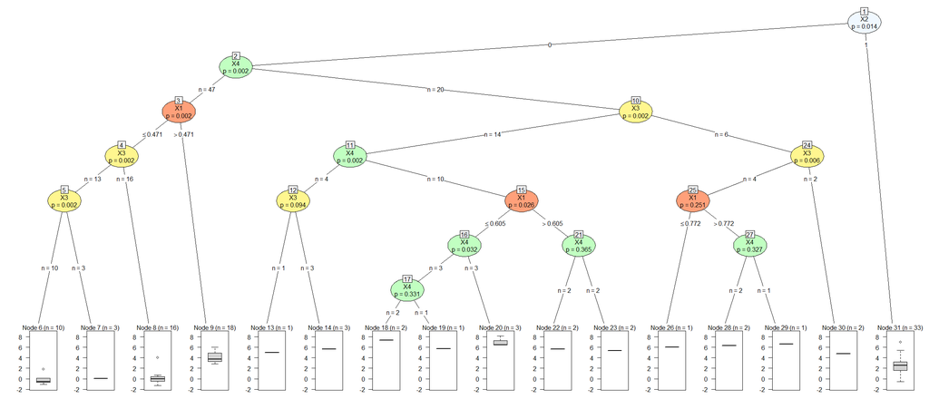

```r
# Plot of a tree from the ensemble
plot(ef_fit$ensemble[[4]])
```

The Out-Of-Bag score for the whole ensemble is stored in `ef_fit`’s element `oob_score`. The performance metric used to compute the OOB score can be retrieved from element `perf_metric`.

```r
# Retrieve performance metric
ef_fit$perf_metric
```

```
#> [1] "MSE"
```

```r
# OOB MSE for this ensemble
ef_fit$oob_score
```

```
#> [1] 1.289393
```

Finally, the ensemble can be used to make predictions using the function `predict()` on `ef_fit`, and possibly specifying a new set of covariates using `newdata`. Any other information, such as the splitting strategy or the type of the task, is automatically retrieved from the fitted object.

Predictions are based either on the fitted values - if `newdata` is not provided - or on the new set of covariates - if `newdata` is specified.

In both cases, each tree in `ef_fit$ensemble` is used to make predictions by calling `predict()` on it (with the same specification of `newdata`). Then, for regression, individual trees’ predictions for single observations are combined by arithmetic mean.

Let’s start with the case where `newdata` is not provided.

```r
# Predictions from the fitted object
pred <- predict(ef_fit)
print(pred)
```

```
#>       10       48       57       85       52       16       34       48
#> 2.679902 4.135738 3.360645 3.106418 2.978768 4.542121 2.108123 2.074140
#>       59       67      107       10       62       25       17       12
#> 3.403327 3.188509 3.822816 2.831832 2.872119 3.641068 3.316160 2.588191
#>       16       17       42       36        7       52        7       44
#> 3.208347 2.627438 2.753697 2.849644 3.053536 1.750992 3.288001 2.565320
#>       14       69       98       42      106       43       64       50
#> 3.494627 4.665498 3.289205 1.789143 2.636787 1.205594 3.731749 3.301720
#>      107       11      101       28       73       99       88       63
#> 2.392789 3.779408 3.386390 2.012728 3.844547 1.957984 3.167867 4.129345
#>       69       34       36       98       86       35       42       29
#> 3.612086 2.768118 3.676978 3.340629 3.766601 2.573598 2.680614 2.176216
#>       85       69       69       38        8       12       34       78
#> 2.571079 3.473253 2.737670 3.507288 2.696437 3.004540 3.006698 3.761995
#>       67       29       42       77       91       14       12       69
#> 4.045500 2.792889 2.320264 4.485125 2.324540 3.569736 4.016510 3.456564
#>       59       51       62       40      100      105       52      109
#> 3.580458 2.103570 2.742141 3.051180 2.831785 3.206117 3.302879 3.207901
#>       27       88      103       77       58        7      108       38
#> 2.385346 2.090764 3.679654 2.736382 2.914928 1.201987 2.023332 2.324558
#>       12       64       77       39       93       65       69       65
#> 3.760490 2.528069 3.394093 3.203227 3.022865 3.431177 3.248708 2.412103
#>       78       92       48       36       75        7       34       50
#> 3.858941 3.241836 3.920557 3.271207 2.604875 3.395582 2.321145 2.585861
#>       67       74       43       44
#> 3.805606 4.150609 2.177344 3.618990
```

However, this case is rarely of practical utility because the model is usually evaluated using the OOB score.

Let’s see an example where predictions are calculated for a new set of covariates.

```r
# New set of covariates
n_obs <- 40
x1n <- c(runif(n_obs / 4, min = 0, max = 0.55),
         runif(n_obs / 4 * 3, min = 0.45, max = 1))
x2n <- factor(c(rbinom(n_obs / 4, 1, 0.1),
                rbinom(n_obs / 4, 1, 0.9),
                rbinom(n_obs / 2, 1, 0.1)))
x3n <- c(fda.usc::rproc2fdata(n_obs / 2, seq(0, 1, len = 100), sigma = 1),
         fda.usc::rproc2fdata(n_obs / 4, seq(0, 1, len = 100), sigma = 1,
                              mu = rep(1, 100)),
         fda.usc::rproc2fdata(n_obs / 4, seq(0, 1, len = 100), sigma = 1))
x4n <- c(lapply(1:(n_obs / 4 * 3), function(j) igraph::sample_gnp(100, 0.1)),
         lapply(1:(n_obs / 4), function(j) igraph::sample_gnp(100, 0.9)))
new_cov_list <- list(X1 = x1n, X2 = x2n, X3 = x3n, X4 = x4n)

# New response
new_resp_reg <- c(rnorm(n_obs / 4, mean = 0, sd = 1),
                  rnorm(n_obs / 4, mean = 2, sd = 1),
                  rnorm(n_obs / 4, mean = 4, sd = 1),
                  rnorm(n_obs / 4, mean = 6, sd = 1))

# Predictions
new_pred <- predict(ef_fit,
                    newdata = new_cov_list)
print(new_pred)
```

```
#>        28        50        42        36        38         7         7         7
#> 0.1861834 2.6370162 0.2083508 0.5578421 0.3257152 0.3634092 0.4702349 0.1322439
#>        11        42        52        12        52        11        57        11
#> 2.6203437 0.6641498 2.2038720 2.4452980 1.9911947 2.2209439 2.1411308 2.3513359
#>        57        50        52        62       100        99        92       100
#> 1.9500233 2.3971748 1.8652271 2.2018243 4.2073993 4.5920318 3.7338271 4.2410766
#>       109       105        88        88        99        99        17        17
#> 3.6221229 4.1800621 4.4216832 4.3556880 3.9694942 4.0655768 5.8279225 5.8652925
#>        16        67        78        69        77        69        16        67
#> 6.0119947 5.8300567 5.9093864 6.1107621 5.9784577 6.2000173 6.1465376 6.0543855
```

We can compare the Mean Square Error between the response and the predicted values with that between the response and its average to see how predictions are on average closer to the actual values than the response.

```r
# MSE between the new response and its average
mean((new_resp_reg - mean(new_resp_reg)) ^ 2)
```

```
#> [1] 6.864907
```

```r
# MSE between the new response and predictions with the new set of covariates
mean((new_resp_reg - new_pred) ^ 2)
```

```
#> [1] 1.40344
```

# Classification

The second example is classification. The set of covariates is the same as before, i.e., `cov_list`, while the response variable is `resp_cls`. Also in this case, the most immediate fit can be obtained by calling `eforest()` and specifying the response and the set of covariates only. Here, we also set `ntrees = 12` to reduce the computational burden and `split_type = “coeff”` to employ the other splitting strategy.

```r
# Quick fit
ef_fit <- eforest(response = resp_cls,
                  covariates = cov_list,
                  ntrees = 12,
                  split_type = 'coeff')
```

While everything else works as for regression, for classification tasks the default performance metric is Balanced Accuracy, while `random_covs` is set to the square root (rounded down) of the number of covariates.

Predictions are obtained using the same commands as for regression. However, internally, individual trees’ predictions for single observations are aggregated by majority voting rule.

```r
# Predictions from the fitted object
pred <- predict(ef_fit)
print(pred)
```

```
#> 34 18 33  7 18  5 19 21 25 18 21 14  7 26 24 14  7 24 31  7  7 10 31 35 35 26
#>  1  2  1  1  4  4  4  2  3  4  3  4  4  2  4  2  1  1  2  2  1  1  1  2  1  1
#>  7 18 14  7  7  7 31 21  5 18 25 31 31 33 34 21 21  7 14  6  7  6 21 34 21 21
#>  1  4  4  1  3  1  1  2  2  4  1  4  3  2  3  2  1  4  4  2  1  2  2  3  2  4
#> 31  7 26 31 21 18  5 21 21  7 24 21 21 21 14  7  7 18 16 18  7 16 34 18  7  7
#>  2  4  1  1  1  1  3  2  2  1  2  1  1  3  1  1  3  4  4  1  4  4  2  2  2  1
#> 29  7 14 33 17 26 18 18  6 19 18  7 18  7 24 18  7 18 34  7 21 21
#>  1  2  1  2  1  4  3  4  1  4  4  2  2  1  2  4  2  4  2  4  2  2
#> Levels: 1 2 3 4
```

To exemplify the use of `predict()` with `newdata`, we can use the new set of covariates generated for regression, coupling it with a new response variable for classification.

```r
# New response
new_resp_cls <- factor(c(sample(x = 1:4, size = n_obs / 4, replace = TRUE,
                                prob = c(0.85, 0.05, 0.05, 0.05)),
                         sample(x = 1:4, size = n_obs / 4, replace = TRUE,
                                prob = c(0.05, 0.85, 0.05, 0.05)),
                         sample(x = 1:4, size = n_obs / 4, replace = TRUE,
                                prob = c(0.05, 0.05, 0.85, 0.05)),
                         sample(x = 1:4, size = n_obs / 4, replace = TRUE,
                                prob = c(0.05, 0.05, 0.05, 0.85))))

# Predictions
new_pred <- predict(ef_fit,
                    newdata = new_cov_list)
print(new_pred)
```

```
#>  7 16  7  7  7  7  7  5 25  7 21 21 21 21 21 21 21 21 21 21 33 29 33 34 29 34
#>  1  3  1  1  1  1  1  1  2  1  2  4  2  4  2  2  2  2  2  2  2  3  3  3  2  3
#> 35 35 31 33 19 18 18 18 18 18 18 14 18 17
#>  3  3  3  2  4  4  4  4  4  4  4  4  4  4
#> Levels: 1 2 3 4
```

```r
# Confusion matrix between the new response and predictions from the fitted tree
table(new_pred, new_resp_cls, dnn = c('Predicted', 'True'))
```

```
#>          True
#> Predicted  1  2  3  4
#>         1  8  0  0  0
#>         2  2  7  2  1
#>         3  1  0  6  1
#>         4  0  2  0 10
```

```r
# Misclassification error for predictions on the new set of covariates
sum(new_pred != new_resp_cls) / length(new_resp_cls)
```

```
#> [1] 0.225
```

In this case, we obtain a misclassification error of 0.225 on test data, which should be however taken with a grain of salt given the very small number of trees that have been used in this toy example.

# References

R. Giubilei, T. Padellini, P. Brutti (2022). Energy Trees: Regression and Classification With Structured and Mixed-Type Covariates. arXiv preprint. https://arxiv.org/pdf/2207.04430.pdf.